# StreamPulse_mean_monthly_data

- Show All Code
- Hide All Code
- View Source

Author

Christa Torrens

## INTRO

The purpose of this script is to get mean monthly values for GPP, ER, NEP and K from the Bernhardt et al. 2018 dataset, “high_quality_daily_metabolism_with_SP_covariates.rds”, AND to combine the three Liu et al. datasets into one long version df to match the monthly streampulse df format, where month (containing values 1-12 repeating), pco2, k, and co2f are columns.

NOTE that the liu_monthly.csv is 2.1 GB, much too large to push to GitHub, so must be downloaded from the Global Carbon google drive (Streams/monthly_datasets folder). https://drive.google.com/drive/folders/1Q2BfLu7UVZgVzcuugHhKcVHC-8mBQKU0

### Load packages

```r
library(tidyverse) # includes dplyr, forcats, ggplot2, lubridate, purrr, readr, stringr, tibble, tidyr
library(here)
library(leaflet)
```

### Load data

```r
# Load streampulse data - metab data
df <- readRDS(here("data/aquatic/streams/AutotrophyProjectFiles/SupplementalData/high_quality_daily_metabolism_with_SP_covariates.rds"))

# Load streampulse data - lat-long/watershed data
ws_df <- read_csv(here("data/aquatic/streams/AutotrophyProjectFiles/across_sites_model_data_annual.csv")) %>%
  distinct(site_name, .keep_all = TRUE) %>%
  select(site_name, lat, lon, Width, NHD_STREAMORDE, NHD_SLOPE, ws_area_km2, ElevWs) %>%
  rename(width = Width,
         stream_order = NHD_STREAMORDE,
         slope = NHD_SLOPE,
         elevWS = ElevWs)

# using these dfs to check for 2 missing ws_df sites:
streampulse_synthesis_statset <- read_csv(here("data/aquatic/streams/AutotrophyProjectFiles/20210902_streampulse_synthesis_statset.csv"))

all_basic_site_data <- read_csv(here("data/aquatic/streams/stream_pulse_DL/all_basic_site_data.csv"))

# Also using the synthesis statset from Autotrophy paper for the average annual GPP and ER values
sp_annual_data <- streampulse_synthesis_statset %>%
  select(sitecode, Name, ann_GPP_C, upper_GPP_C, ann_ER_C, lower_ER_C) %>%
  rename(site_name = sitecode, long_name = Name, ann_GPP = ann_GPP_C, ann_GPP.upper = upper_GPP_C,
         ann_ER = ann_ER_C, ann_ER.lower = lower_ER_C)


# Load the monthly pCO2, CO2f, and K values from Liu et al.
liu_pco2 <- read_csv(here("data/aquatic/streams/Liu_data_DL_v20210902/pco2.csv"))
liu_co2f <- read_csv(here("data/aquatic/streams/Liu_data_DL_v20210902/co2f.csv"))
liu_k <- read_csv(here("data/aquatic/streams/Liu_data_DL_v20210902/k.csv"))
```

### Scale mean daily to monthly values for GPP, ER; calc mean monthly for NEP and K600

#### compare dataframes

```r
# Calculate the average daily values by month for each site (for GPP, ER, NEP and K600)
# How to scale up to monthly data?

# Check to see which sites are in both dfs:

monthly_only_sites <- monthly_avg_df %>%
  anti_join(sp_annual_data, by = "site_name")

print(unique(monthly_only_sites[,1:2]))

#    site_name            long_name
#    <chr>                <chr>
#  1 nwis_01656903        FLATLICK BRANCH ABOVE FROG BRANCH AT CHANTILLY, VA
#  2 nwis_02336120        N.F. PEACHTREE CREEK, BUFORD HWY, NEAR ATLANTA, GA
#  3 nwis_02336152        SOUTH FORK PEACHTREE AT CASA DR, NR CLARKSTON, GA
#  4 nwis_023362095       BURNT FORK CR AT MILLWOOD WAY NEAR CLARKSTON, GA
#  5 nwis_02336240        S.F. PEACHTREE CREEK JOHNSON RD, NEAR ATLANTA, GA
#  6 nwis_03098600        Mahoning River below West Ave at Youngstown OH
#  7 nwis_040871488       WILSON PARK CK @ ST. LUKES HOSPITAL @ MILWAUKEE,WI
#  8 nwis_04174500        HURON RIVER AT ANN ARBOR, MI
#  9 nwis_04199500        Vermilion River near Vermilion OH
# 10 nwis_04231600        GENESEE RIVER AT FORD STREET BRIDGE, ROCHESTER NY
# 11 nwis_06711565        SOUTH PLATTE RIVER AT ENGLEWOOD, CO.
# 12 nwis_06893300        INDIAN C AT OVERLAND PARK, KS
# 13 nwis_08057000        Trinity Rv at Dallas, TX
# 14 nwis_12101100        LAKE TAPPS DIVERSION AT DIERINGER, WA
# 15 nwis_13206400        EAGLE DRAIN AT EAGLE, ID
# 16 nwis_385520094420000 INDIAN C AT COLLEGE BLVD, JOHNSON CO, KS


annual_only_sites <- sp_annual_data %>%
  anti_join(monthly_avg_df, by = "site_name")

print(unique(annual_only_sites[,1:2]))
#    site_name     long_name
#    <chr>         <chr>
#  1 AZ_LV         Lower Verde River
#  2 AZ_OC         Oak Creek
#  3 AZ_WB         Wet Beaver Creek
#  4 FL_SF2500     Santa Fe 2500
#  5 FL_SF2800     Santa Fe 2800
#  6 FL_WS1500     Worthington Springs 1500
#  7 IN_SDW        Shatto Ditch Watershed-twostage
#  8 MD_DRKR       Dead Run
#  9 NC_NHC        New Hope Creek
# 10 NC_UNHC       Upper New Hope Creek
# 11 NH_DCF        Dowst- Cate Town Forest Stream
# 12 NH_GOF        Merrimack River at Goffs Falls
# 13 nwis_01493112 CHESTERVILLE BRANCH NEAR CRUMPTON, MD
# 14 nwis_02235500 BLUE SPRINGS NEAR ORANGE CITY, FL
# 15 WI_BEC        Black Earth Creek
# 16 WI_BRW        Brewery Creek
```

These sites are in the monthly df (from high_quality_daily_metabolism_with_SP_covariates.rds) but not the annual df (from 20210902_streampulse_synthesis_statset.csv): site_name long_name  
1 nwis_01656903 FLATLICK BRANCH ABOVE FROG BRANCH AT CHANTILLY, VA 2 nwis_02336120 N.F. PEACHTREE CREEK, BUFORD HWY, NEAR ATLANTA, GA 3 nwis_02336152 SOUTH FORK PEACHTREE AT CASA DR, NR CLARKSTON, GA 4 nwis_023362095 BURNT FORK CR AT MILLWOOD WAY NEAR CLARKSTON, GA  
5 nwis_02336240 S.F. PEACHTREE CREEK JOHNSON RD, NEAR ATLANTA, GA 6 nwis_03098600 Mahoning River below West Ave at Youngstown OH  
7 nwis_040871488 WILSON PARK CK @ ST. LUKES HOSPITAL @ MILWAUKEE,WI 8 nwis_04174500 HURON RIVER AT ANN ARBOR, MI  
9 nwis_04199500 Vermilion River near Vermilion OH  
10 nwis_04231600 GENESEE RIVER AT FORD STREET BRIDGE, ROCHESTER NY 11 nwis_06711565 SOUTH PLATTE RIVER AT ENGLEWOOD, CO.  
12 nwis_06893300 INDIAN C AT OVERLAND PARK, KS  
13 nwis_08057000 Trinity Rv at Dallas, TX  
14 nwis_12101100 LAKE TAPPS DIVERSION AT DIERINGER, WA  
15 nwis_13206400 EAGLE DRAIN AT EAGLE, ID  
16 nwis_385520094420000 INDIAN C AT COLLEGE BLVD, JOHNSON CO, KS

These sites are in the annual df (from 20210902_streampulse_synthesis_statset.csv) but not the monthly (from high_quality_daily_metabolism_with_SP_covariates.rds): site_name long_name 1 AZ_LV Lower Verde River 2 AZ_OC Oak Creek 3 AZ_WB Wet Beaver Creek 4 FL_SF2500 Santa Fe 2500 5 FL_SF2800 Santa Fe 2800 6 FL_WS1500 Worthington Springs 1500 7 IN_SDW Shatto Ditch Watershed-twostage 8 MD_DRKR Dead Run 9 NC_NHC New Hope Creek 10 NC_UNHC Upper New Hope Creek 11 NH_DCF Dowst- Cate Town Forest Stream 12 NH_GOF Merrimack River at Goffs Falls 13 nwis_01493112 CHESTERVILLE BRANCH NEAR CRUMPTON, MD 14 nwis_02235500 BLUE SPRINGS NEAR ORANGE CITY, FL 15 WI_BEC Black Earth Creek 16 WI_BRW Brewery Creek

There are two versions of the monthly file: the _trimmed file ONLY includes sites in both the monthly and annual dfs. I retained the other in case we can find and insert annual average GPP and ER, thus determine monthly average GPP, ER, and NEP for the 16 sites w/o those data

#### scale ER and GPP

```r
# days in each month (1 = Jan : 12 = Dec)
days_in_month <- c(31,28,31,30,31,30,31,31,30,31,30,31)

# Average K, scale GPP and ER, calculate NEP as ER(neg) + GPP(pos)
monthly_avg_df <- df %>%
  mutate(month = month(date)) %>%  # Extract the month from the date column
  group_by(site_name, long_name, month) %>%  # Group by site_name, and month
  summarize(
    avgday_GPP = mean(GPP, na.rm = TRUE),
    avgday_GPP.lower = mean(GPP.lower, na.rm = TRUE),
    avgday_GPP.upper = mean(GPP.upper, na.rm = TRUE),
    avgday_ER = mean(ER, na.rm = TRUE),
    avgday_ER.lower = mean(ER.lower, na.rm = TRUE),
    avgday_ER.upper = mean(ER.upper, na.rm = TRUE),
    avgday_NEP = avgday_ER + avgday_GPP,
    avg_K600 = mean(K600, na.rm = TRUE),
    avg_K600.lower = mean(K600.lower, na.rm = TRUE),
    avg_K600.upper = mean(K600.upper, na.rm = TRUE),

    # Add counts of non-missing values
    ndays_GPP  = sum(!is.na(GPP)),
    ndays_ER   = sum(!is.na(ER)),
    ndays_K600 = sum(!is.na(K600)),

    # Number of unique years of data in each site/month group (sp = streampulse)
    nyear_sp  = n_distinct(year(date)),


    .groups = "drop"  # Drops the grouping after summarizing
    ) %>%

   # Scale to monthly totals
   mutate(days = days_in_month[month],
          GPP_monthly_scaled = avgday_GPP * days,
          GPP_monthly_scaled.lower = avgday_GPP.lower * days,
          GPP_monthly_scaled.upper = avgday_GPP.upper * days,
          ER_monthly_scaled = avgday_ER * days,
          ER_monthly_scaled.lower = avgday_ER.lower * days,
          ER_monthly_scaled.upper = avgday_ER.upper * days,
          NEP_monthly_scaled = ER_monthly_scaled + GPP_monthly_scaled
          ) %>%
  group_by(site_name) %>%
  mutate(
    frac_GPP = GPP_monthly_scaled / sum(GPP_monthly_scaled, na.rm = TRUE),
    frac_ER  = ER_monthly_scaled  / sum(ER_monthly_scaled,  na.rm = TRUE)
  ) %>%
  ungroup() %>%

  left_join(
    sp_annual_data, by = c("site_name", "long_name")) %>%
  mutate(
    GPP_monthly_norm = frac_GPP * ann_GPP,
    ER_monthly_norm  = frac_ER  * ann_ER,
    NEP_monthly_norm = ER_monthly_norm + GPP_monthly_norm
  ) %>%

  select(
    1:3,                                   # keep first three columns in place
    GPP_monthly_scaled,
    ER_monthly_scaled,
    NEP_monthly_scaled,
    GPP_monthly_norm,
    ER_monthly_norm,
    NEP_monthly_norm,
    avg_K600,
    avg_K600.lower,
    avg_K600.upper,
    ndays_GPP,
    ndays_ER,
    ndays_K600,
    nyear_sp,
    everything(),                            # then all remaining columns
  ) %>%
  select(!days)

# 222 sites, based on sites in the Autotrophy project's high_quality_daily_metabolism_with_SP_covariates.rds file
```

### Add lat-lon and watershed data

Extract key information from across_sites_model_data and join with monthly_avg_data Determine missing info from both dfs

```r
monthly_avg_df <- monthly_avg_df %>%
  left_join(ws_df, by = "site_name") %>%
  relocate(lat, lon, .after = 2)  %>% # put lat and lon after the 2nd column
  select(1:15,            # first 15 columns
         35:39,           # columns to move up
         everything()     # all remaining columns
         )

# trim one dataset to sites that are in both annual and monthly datasets

monthly_avg_df_trimmed <- monthly_avg_df %>%
  semi_join(sp_annual_data, by = "site_name")
# 206 sites


# check to see if there are sites w/o ws info in the merged df
missing_sites <- monthly_avg_df %>%
  anti_join(ws_df, by = "site_name")

unique(missing_sites$site_name)
```

```
[1] "nwis_12101100" "nwis_13206400"
```

```r
# "nwis_12101100" "nwis_13206400"

missing_sites_trimmed <- monthly_avg_df_trimmed %>%
  anti_join(ws_df, by = "site_name")

unique(missing_sites_trimmed$site_name)
```

```
character(0)
```

```r
# None

## MISSING ws data for "nwis_12101100" "nwis_13206400"

# Checking to see if these sites are in two other source StreamPulse datasets
still_missing <-missing_sites %>%
  anti_join(streampulse_synthesis_statset,
            by = c("site_name" = "sitecode"))

unique(still_missing$site_name)
```

```
[1] "nwis_12101100" "nwis_13206400"
```

```r
still_missing2 <- missing_sites %>%
  anti_join(all_basic_site_data,
            by = c("site_name" = "siteID"))

unique(still_missing2$site_name)
```

```
[1] "nwis_12101100" "nwis_13206400"
```

```r
# "nwis_12101100" "nwis_13206400"  => both sites still missing from the two additional dataframes
# long_name = "LAKE TAPPS DIVERSION AT DIERINGER, WA" "EAGLE DRAIN AT EAGLE, ID"
# Sounds like these may not have been free-flowing rivers... maybe dam impacted?


# also, what's missing from the monthly summary df that IS in the ws_df?

missing_WSs <- ws_df %>%
  anti_join(monthly_avg_df, by = "site_name")

unique(missing_WSs$site_name)
```

```
 [1] "AZ_LV"         "AZ_OC"         "AZ_WB"         "FL_SF2500"
 [5] "FL_SF2800"     "FL_WS1500"     "IN_SDW"        "MD_DRKR"
 [9] "NC_NHC"        "NC_UNHC"       "NH_DCF"        "NH_GOF"
[13] "nwis_01493112" "nwis_02235500" "WI_BEC"        "WI_BRW"
```

```r
# "AZ_LV"         "AZ_OC"         "AZ_WB"         "FL_SF2500"     "FL_SF2800"     "FL_WS1500"     "IN_SDW"       "MD_DRKR"       "NC_NHC"        "NC_UNHC"       "NH_DCF"        "NH_GOF"        "nwis_01493112"     "nwis_02235500" "WI_BEC"        "WI_BRW"

# None of these are in the 'high quality daily metabolism...' source file, although apparently were included in the Autotrophy paper; not sure where to find the daily data for any of them.
```

The ‘monthly_avg_df’ and parent file, ‘high_quality_daily_metabolism_with_SP_covariates.rds’ (loaded as ‘df’) are both missing multiple sites that were in other Autotrophy datasets, including ‘across_sites_model_data_annual.csv’, 20210902_streampulse_synthesis_statset.csv, and ‘SupplementalData/across_sites_model_data_annual.csv’. These sites are: “AZ_LV”, “AZ_OC”, “AZ_WB”, “FL_SF2500”, “FL_SF2800”, “FL_WS1500”, “IN_SDW”, “MD_DRKR”, “NC_NHC”, “NC_UNHC”, “NH_DCF”, “NH_GOF”, “nwis_01493112” “nwis_02235500”, “WI_BEC”, “WI_BRW”. Most but not all are StreamPulse core sites and not Powell Center sites. I have not been able to locate daily or monthly data for these sites in eithe rthe Autotrophy paper files or the StreamPulse files.

Also, ‘monthly_avg_df’ and parent file *contain* two sites that were not in the other Autotrophy files. Those sites are: nwis_12101100, “LAKE TAPPS DIVERSION AT DIERINGER, WA”, and nwis_13206400, “EAGLE DRAIN AT EAGLE, ID”.

### Reformat and merge Liu et al. dataframes

Change to long format, to match the StreamPulse monthly summaries; then merge by COMID.

```r
# pCO2 data
pco2_long <- liu_pco2 %>%
  pivot_longer(
    cols = -COMID,
    names_to = "month",
    values_to = "pCO2_liu"
  ) %>%
  mutate(
    # extract the numeric part after "co2_"
    month = as.integer(str_extract(month, "(?<=co2_)\\d+"))
  )

nrow(pco2_long) # 34781988

missing_pco2 <- k_long %>%
  anti_join(pco2_long, by = "COMID") %>%
  mutate(COMID = as.integer(COMID))


unique(missing_pco2$COMID)
# 31000001 61000003

# K data
k_long <- liu_k %>%
  pivot_longer(
    cols = -COMID,
    names_to = "month",
    values_to = "k_liu"
  ) %>%
  mutate(
    month = str_remove(month, "_k"),  # remove the "_k" suffix
    month = match(month, month.abb)   # convert "Jan" -> 1, etc.
  )

nrow(k_long) # 34782012


missing_k <- pco2_long %>%
  anti_join(k_long, by = "COMID")
# Empty

# CO2 flux data
co2f_long <- liu_co2f %>%
  pivot_longer(
    cols = -COMID,                     # all columns except COMID
    names_to = "month",                # new column name for the original column names
    values_to = "co2flux_liu"                    # new column for the values
  ) %>%
    mutate(
    month = str_remove(month, "_co2f"),  # remove the "_co2f" suffix
    month = match(month, month.abb)      # convert "Jan" -> 1, etc.
  )

nrow(co2f_long) #34738248


# hm, different lengths... odd.
missing_co2f <- k_long %>%
  anti_join(co2f_long, by = "COMID")

unique(missing_co2f$COMID)


# Left-join to combine the dataframes, pCO2, k, co2f (order ensures complete pco2 and k)

liu_data_long <- pco2_long %>%
  left_join(k_long, by = c("COMID", "month")) %>%
  left_join(co2f_long, by = c("COMID", "month"))

nrow(liu_data_long) # 34781988 - same as pco2_long, as expected
```

### Save the dataframes as CSVs

```r
write_csv(monthly_avg_df, here("data/aquatic/streams/monthly_datasets/streampulse_monthly.csv"))
write_csv(monthly_avg_df_trimmed, here("data/aquatic/streams/monthly_datasets/streampulse_monthly_trimmed.csv"))
write_csv(liu_data_long, here("data/aquatic/streams/monthly_datasets/liu_monthly.csv"))
```

### Comparing two methods for attaining monthly values

Monthly GPP and ER values were calculated two different ways: 1) group by site and month, average all values in a month to get an average daily value for that site and month, then multiply by the # of days in the month; and 2) take that scaled monthly value and normalize it using the Autotrophy paper’s annualized GPP and ER values for each site. Comparison plots for the two methods follow; the dashed red line is the 1:1 line.

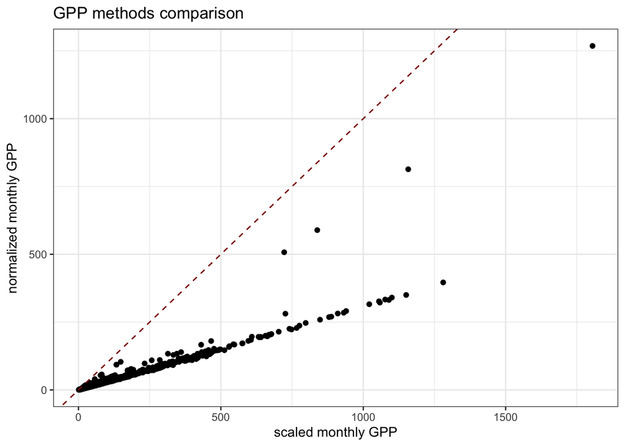

```r
compare_GPP <- monthly_avg_df_trimmed %>%
  ggplot(aes(x=GPP_monthly_scaled, y=GPP_monthly_norm)) +
  geom_point() +
  geom_abline(intercept = 0, slope = 1, color = "darkred", linetype = "dashed") +
  labs(title = "GPP methods comparison",
       x = "scaled monthly GPP",
       y = "normalized monthly GPP") +
  theme_bw()

# quartz()
compare_GPP
```

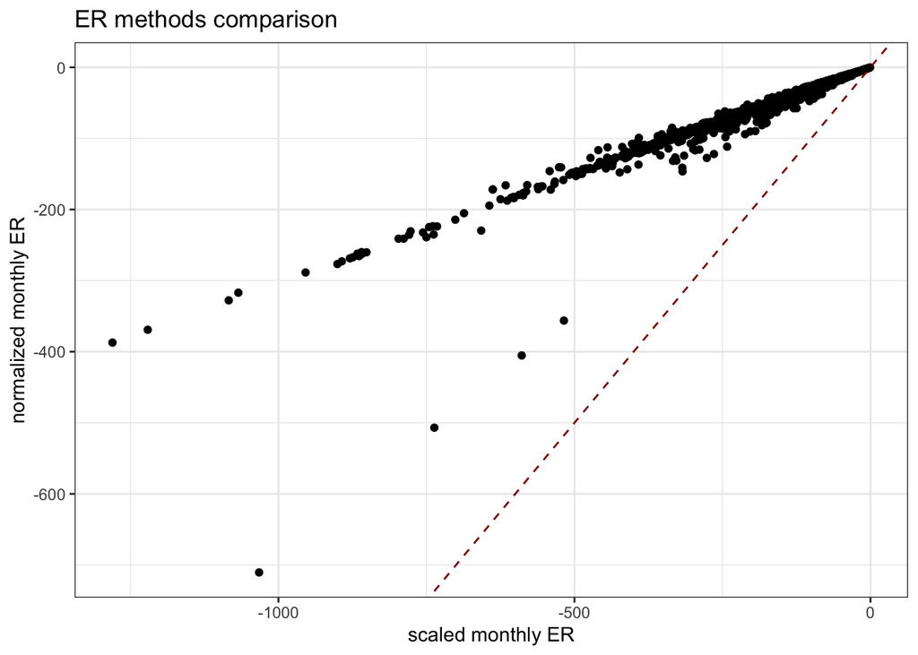

```r
compare_ER <- monthly_avg_df_trimmed %>%
  ggplot(aes(x=ER_monthly_scaled, y=ER_monthly_norm)) +
  geom_point() +
  geom_abline(intercept = 0, slope = 1, color = "darkred", linetype = "dashed") +
    labs(title = "ER methods comparison",
       x = "scaled monthly ER",
       y = "normalized monthly ER") +
  theme_bw()

# quartz()
compare_ER
```

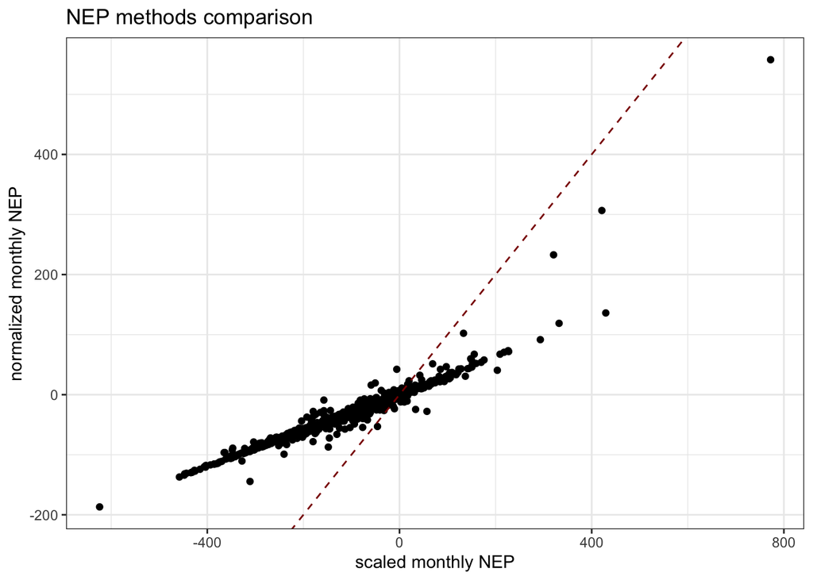

```r
compare_NEP <- monthly_avg_df_trimmed %>%
  ggplot(aes(x=NEP_monthly_scaled, y=NEP_monthly_norm)) +
  geom_point() +
  geom_abline(intercept = 0, slope = 1, color = "darkred", linetype = "dashed") +
    labs(title = "NEP methods comparison",
       x = "scaled monthly NEP",
       y = "normalized monthly NEP") +
  theme_bw()

# quartz()
compare_NEP
```

### Site location mapping

```r
## where are these sites?


map_df <- monthly_avg_df_trimmed %>%
  select(site_name, long_name, lat, lon) %>%
  # Create a popup column
  mutate(popup = paste0(
    "<b>Site:</b> ", site_name, "<br/>",
    "<b>Name:</b> ", long_name, "<br/>"
    # ,
    # "<b>COMID:</b> ", COMID
  ))


# Create interactive map with OpenStreetMap tiles
leaflet(map_df) %>%
  addTiles() %>%  # default is OpenStreetMap
  addMarkers(lng = ~lon, lat = ~lat, popup = ~popup) %>%
  fitBounds(lng1 = min(map_df$lon), lat1 = min(map_df$lat),
            lng2 = max(map_df$lon), lat2 = max(map_df$lat))
```

[interactive chart not shown]